# Supervised learning: Regression 1

# Introduction

In this practical, you will learn how to perform regression analysis, how to plot with confidence and prediction intervals, how to calculate MSE, perform train-test splits, and write a function for cross validation.

Just like in the practical at the end of chapter 3 of the ISLR book, we will use the `Boston` dataset, which is in the `MASS` package that comes with `R`.

```r
library(ISLR)
library(MASS)
library(tidyverse)
```

# Regression in `R`

Regression is performed through the `lm()` function. It requires two arguments: a `formula` and `data`. A `formula` is a specific type of object that can be constructed like so:

```r
some_formula <- outcome ~ predictor_1 + predictor_2
```

You can read it as “the outcome variable is a function of predictors 1 and 2”. As with other objects, you can check its class and even convert it to other classes, such as a character vector:

```r
class(some_formula)
```

```
## [1] "formula"
```

```r
as.character(some_formula)
```

```
## [1] "~"                         "outcome"
## [3] "predictor_1 + predictor_2"
```

A linear model can thus be generated by specifying the outcome variable and the predictors in a formula and specifying the dataset these variables should be taken from.

**Create a linear model object called `lm_ses` that estimates the formula `medv ~ lstat` using the `Boston` dataset**

```r
lm_ses <- lm(medv ~ lstat, data = Boston)
```

You have now run a regression with `medv` (housing value) as the outcome/dependent variable and `lstat` (socio-economic status) as the predictor / independent variable.

Remember that a regression estimates $\beta_0$ (the intercept) and $\beta_1$ (the slope) in the following equation:

$$\boldsymbol{y} = \beta_0 + \beta_1\cdot \boldsymbol{x}_1 + \boldsymbol{\epsilon}$$

**Use the function `coef()` to extract the intercept and slope from the `lm_ses` object. Interpret the slope coefficient.**

```r
coef(lm_ses)
```

```
## (Intercept)       lstat
##  34.5538409  -0.9500494
```

**Use `summary()` to get a summary of the `lm_ses` object. What do you see? You can use the help file `?summary.lm`.**

```r
summary(lm_ses)
```

```
##
## Call:
## lm(formula = medv ~ lstat, data = Boston)
##
## Residuals:
##     Min      1Q  Median      3Q     Max
## -15.168  -3.990  -1.318   2.034  24.500
##
## Coefficients:
##             Estimate Std. Error t value Pr(>|t|)
## (Intercept) 34.55384    0.56263   61.41   <2e-16 ***
## lstat       -0.95005    0.03873  -24.53   <2e-16 ***
## ---
## Signif. codes:  0 '***' 0.001 '**' 0.01 '*' 0.05 '.' 0.1 ' ' 1
##
## Residual standard error: 6.216 on 504 degrees of freedom
## Multiple R-squared:  0.5441, Adjusted R-squared:  0.5432
## F-statistic: 601.6 on 1 and 504 DF,  p-value: < 2.2e-16
```

Because we now have a model object that represents the formula

$$\text{medv}_i = 34.55 - 0.95 * \text{lstat}_i + \epsilon_i$$

we can predict a new `medv` value by simply inputting any `lstat` value. The `predict()` method allows us to quickly do this for the `lstat` values in the original dataset.

**Save the predicted y values to a variable called `y_pred`**

```r
y_pred <- predict(lm_ses)
```

**Create a scatter plot with `y_pred` mapped to the x position and the true y value (`Boston$medv`) mapped to the y value. What do you see? What would this plot look like if the fit were perfect?**

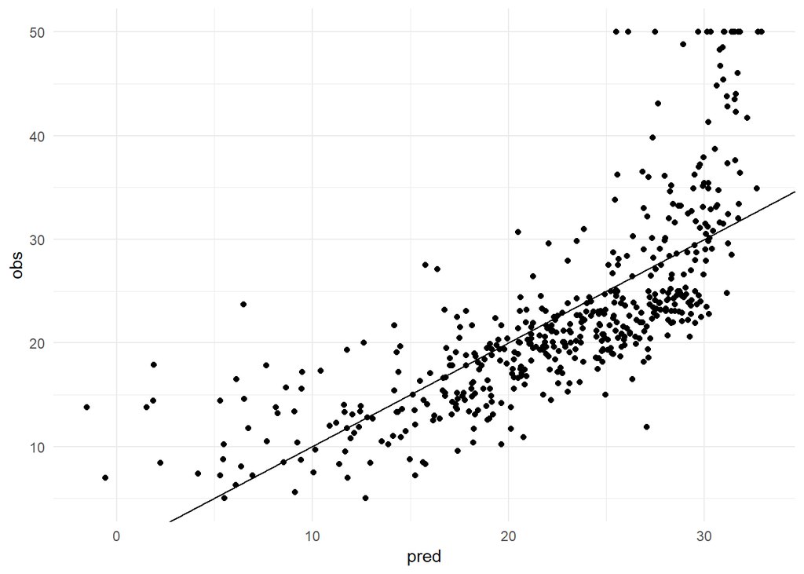

```r
tibble(pred = y_pred,
       obs  = Boston$medv) %>%
  ggplot(aes(x = pred, y = obs)) +
  geom_point() +
  theme_minimal() +
  geom_abline(slope = 1)
```

```r
# I've added an ideal line where all the points would lie if the
# fit were perfect.
```

We can also generate predictions from new data using the `newdat` argument. For that, we need to prepare a data frame with new values for the original predictors.

```r
pred_dat <- tibble(lstat = seq(0, 40, length.out = 1000))
```

**Use the newly created data frame as the `newdata` argument to a `predict()` call for `lm_ses`. Store it in a variable named `y_pred_new`.**

```r
y_pred_new <- predict(lm_ses, newdata = pred_dat)
```

# Plotting lm() in `ggplot`

A good way of understanding your model is by visualising it. We are going to walk through the construction of a plot with a fit line and prediction / confidence intervals from an `lm` object.

**Create a scatter plot from the `Boston` dataset with `lstat` mapped to the x position and `medv` mapped to the y position. Store the plot in an object called `p_scatter`.**

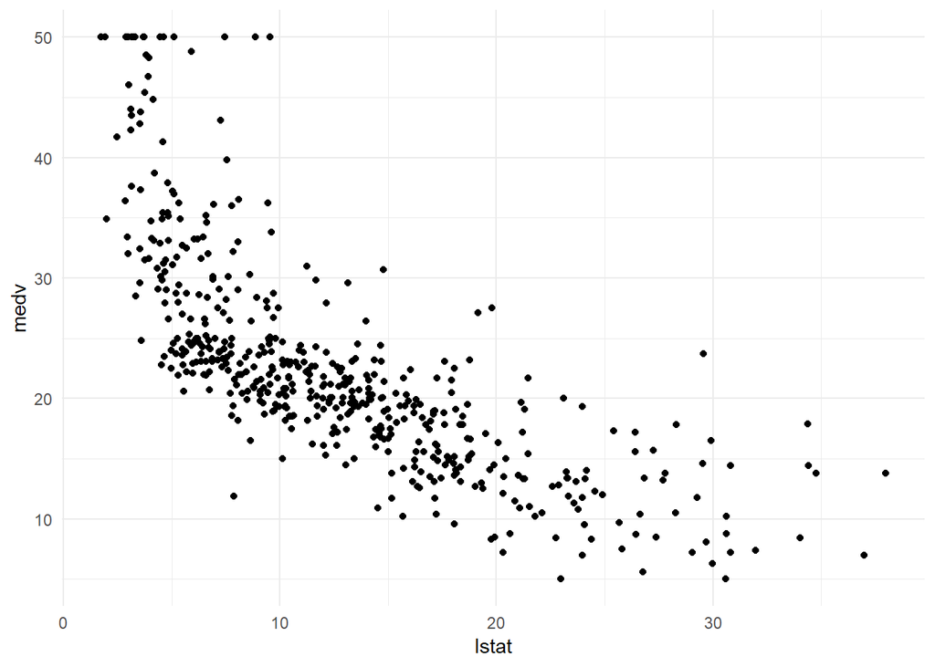

```r
p_scatter <-
  Boston %>%
  ggplot(aes(x = lstat, y = medv)) +
  geom_point() +
  theme_minimal()

p_scatter
```

Now we’re going to add a prediction line to this plot.

**Add the vector `y_pred_new` to the `pred_dat` data frame with the name `medv`.**

```r
# this can be done in several ways. Here are two easy ones:
# pred_dat$medv <- y_pred_new
pred_dat <- pred_dat %>% mutate(medv = y_pred_new)
```

**Add a geom_line() to `p_scatter`, with `pred_dat` as the `data` argument. What do you see?**

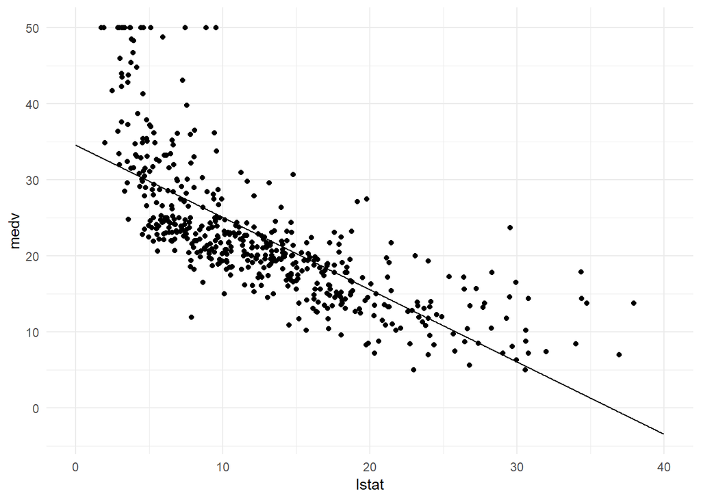

```r
p_scatter + geom_line(data = pred_dat)
```

**The `interval` argument can be used to generate confidence or prediction intervals. Create a new object called `y_pred_95` using `predict()` (again with the `pred_dat` data) with the `interval` argument set to “confidence”. What is in this object?**

```r
y_pred_95 <- predict(lm_ses, newdata = pred_dat, interval = "confidence")

head(y_pred_95)
```

```
##        fit      lwr      upr
## 1 34.55384 33.44846 35.65922
## 2 34.51580 33.41307 35.61853
## 3 34.47776 33.37768 35.57784
## 4 34.43972 33.34229 35.53715
## 5 34.40168 33.30690 35.49646
## 6 34.36364 33.27150 35.45578
```

```r
# it's a matrix with an estimate and a lower and an upper confidence interval.
```

**Create a data frame with 4 columns: `medv`, `lstat`, `lower`, and `upper`.**

```r
gg_pred <- tibble(
  lstat = pred_dat$lstat,
  medv  = y_pred_95[, 1],
  l95   = y_pred_95[, 2],
  u95   = y_pred_95[, 3]
)

gg_pred
```

| lstat | medv | l95 | u95 |
| --- | --- | --- | --- |
| 0.00000000 | 34.55384088 | 33.44845704 | 35.659224718 |
| 0.04004004 | 34.51580087 | 33.41307021 | 35.618531522 |
| 0.08008008 | 34.47776085 | 33.37768134 | 35.577840367 |
| 0.12012012 | 34.43972084 | 33.34229041 | 35.537151267 |
| 0.16016016 | 34.40168082 | 33.30689741 | 35.496464237 |
| 0.20020020 | 34.36364081 | 33.27150232 | 35.455779293 |
| 0.24024024 | 34.32560079 | 33.23610514 | 35.415096449 |
| 0.28028028 | 34.28756078 | 33.20070584 | 35.374415721 |
| 0.32032032 | 34.24952077 | 33.16530441 | 35.333737124 |
| 0.36036036 | 34.21148075 | 33.12990083 | 35.293060675 |

[output cut: 990 more lines]

**Add a `geom_ribbon()` to the plot, below the `geom_line()` and the `geom_points()` of before. Give it a nice colour and clean up the plot, too!**

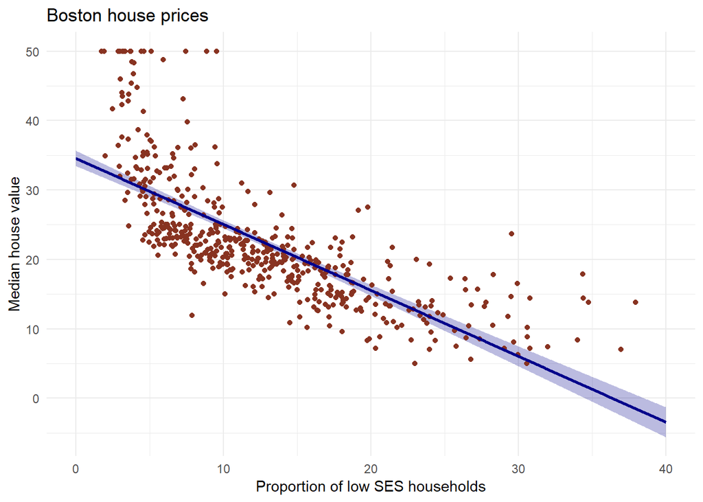

```r
# Create the plot
Boston %>%
  ggplot(aes(x = lstat, y = medv)) +
  geom_ribbon(aes(ymin = l95, ymax = u95), data = gg_pred, fill = "#00008b44") +
  geom_point(colour = "#883321") +
  geom_line(data = pred_dat, colour = "#00008b", size = 1) +
  theme_minimal() +
  labs(x    = "Proportion of low SES households",
       y    = "Median house value",
       title = "Boston house prices")
```

**Do the same thing, but now with the prediction interval instead of the confidence interval.**

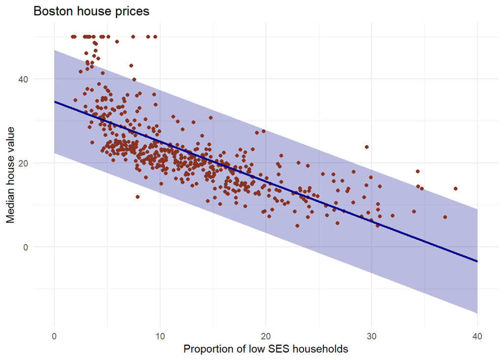

```r
# pred with pred interval
y_pred_95 <- predict(lm_ses, newdata = pred_dat, interval = "prediction")


# create the df
gg_pred <- tibble(
  lstat = pred_dat$lstat,
  medv  = y_pred_95[, 1],
  l95   = y_pred_95[, 2],
  u95   = y_pred_95[, 3]
)

# Create the plot
Boston %>%
  ggplot(aes(x = lstat, y = medv)) +
  geom_ribbon(aes(ymin = l95, ymax = u95), data = gg_pred, fill = "#00008b44") +
  geom_point(colour = "#883321") +
  geom_line(data = pred_dat, colour = "#00008b", size = 1) +
  theme_minimal() +
  labs(x    = "Proportion of low SES households",
       y    = "Median house value",
       title = "Boston house prices")
```

# Mean square error

Write a function called `mse()` that takes in two vectors: true y values and predicted y values, and which outputs the mean square error. Start like so:

```r
mse <- function(y_true, y_pred) {
  # your function here
}
```

[Wikipedia](https://en.wikipedia.org/w/index.php?title=Mean_squared_error&oldid=857685443) may help for the formula.

```r
# there are many ways of doing this.
mse <- function(y_true, y_pred) {
  mean((y_true - y_pred)^2)
}
```

**Make sure your `mse()` function works correctly by running the following code.**

```r
mse(1:10, 10:1)
```

```
## [1] 33
```

You have now calculated the mean squared length of the dashed lines below.

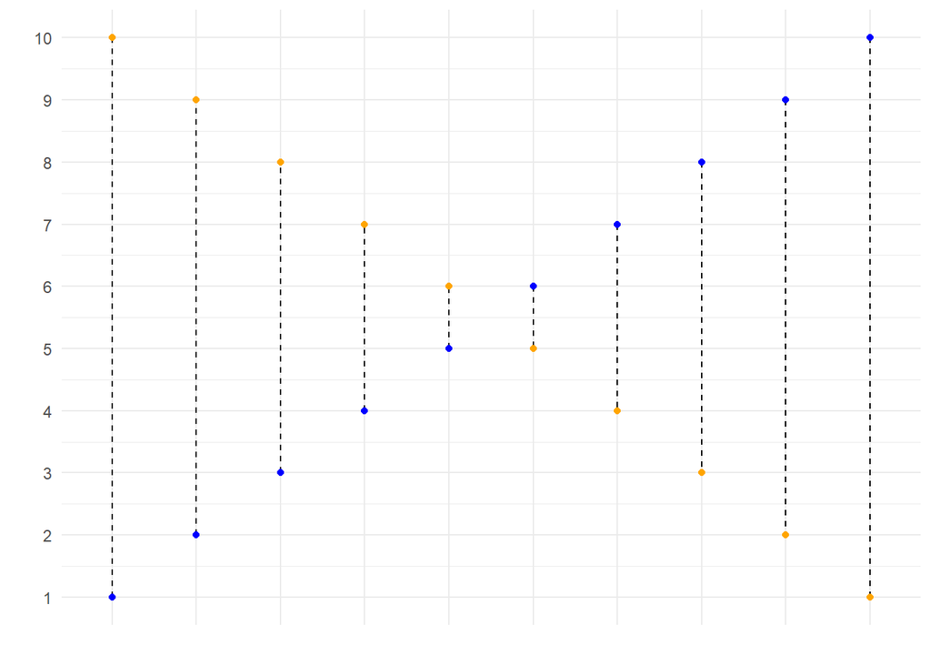

**Calculate the mean square error of the `lm_ses` model. Use the `medv` column as `y_true` and use the `predict()` method to generate `y_pred`.**

```r
mse(Boston$medv, predict(lm_ses))
```

```
## [1] 38.48297
```

You have calculated the mean squared length of the dashed lines in the plot below

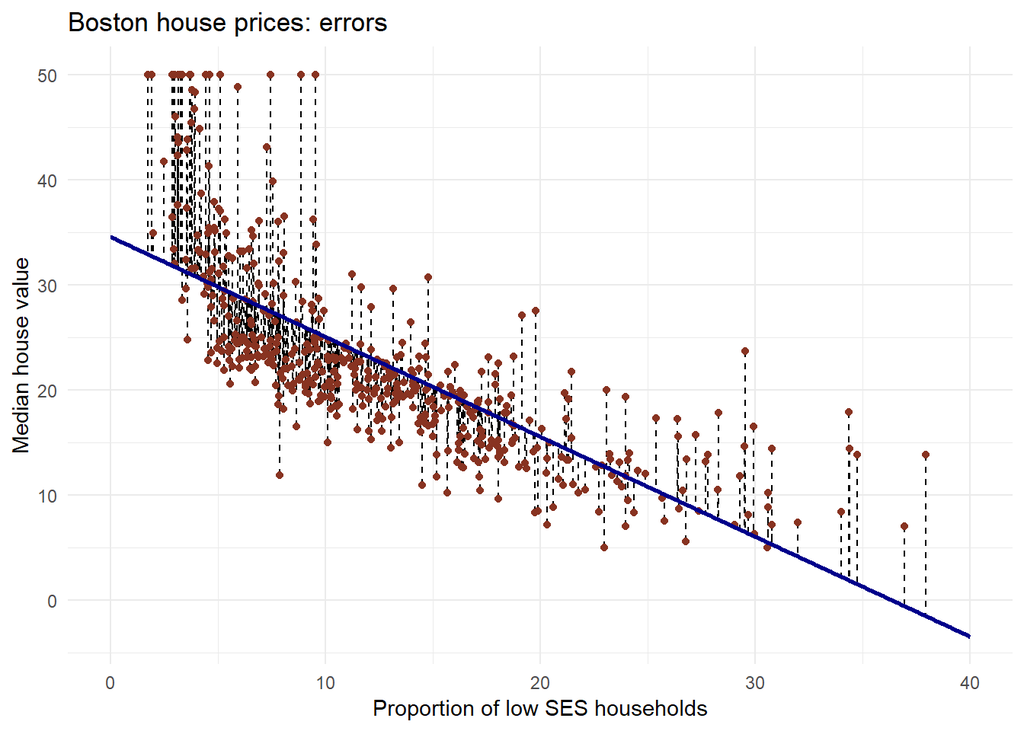